# Transportation analysis in the Bay Area

Spencer Zhang

12/4/2021

### Introduction & Background

In this mini project, we want to get some preliminary insights into the transportation accessibility and commute behavior in the Bay Area, with a specific focus on public transportation.

First, we take a general overlook into the commute means makeup among the Bay Area workers. As shown in the figure below, more than half of the Bay Area workers drive alone to work, a transportation habit that accounts for major greenhouse emissions. Only less than a quarter of the worker population take public transportation to work.

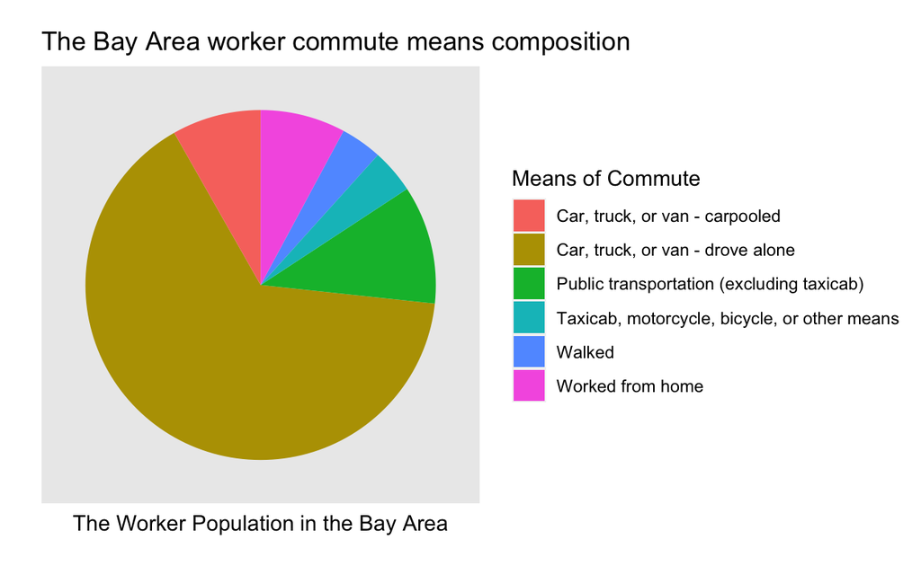

Fig.1 The Bay Area worker commute means composition

It is intuitively plausible that the distance between one’s place of work and residence would in some way affect choices of commute. The work/home location situation in the Bay Area is outlined in Figure 2. Nearly 2/3 of the worker population reside in the same county of their work place. With the great number of people living relatively adjacent to their work place, one would expect a higher preference to the public transportation system since it’s easier to access and time-efficient within one single county area, however the statistics here show the opposite.

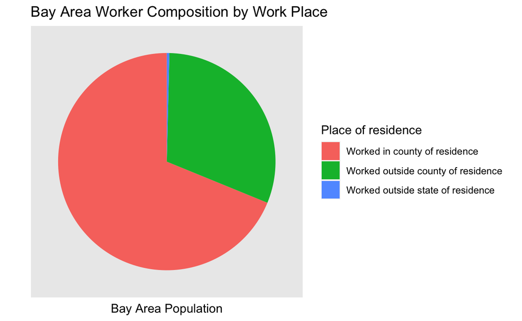

What would be the underlying issue that hinders the Bay Area population’s enthusiasm to take the public transportation? What factors influence the worker’s choice of commute transportation? Does people of different working conditions, socioeconomic status, and identities make different choices when it comes to transportation? Further analysis and personal interpretation is presented below for readers’ reference.

### Possible influencing factor inspection

#### Means of transportation by work/home distance

The population show different preferences to different transportation means when they reside inside or outside the county of their workplace, outlined in Figure 2. What is interesting about this figure is that among people taking public transportation, there are more people who live far from the place of work. There might be other confounding factors such as income. One hypothesis is that people with lower income tend to reside in places with lower rent, where might be far from their working location; thus they tend to watch their daily expenses more and may likely not have a car.

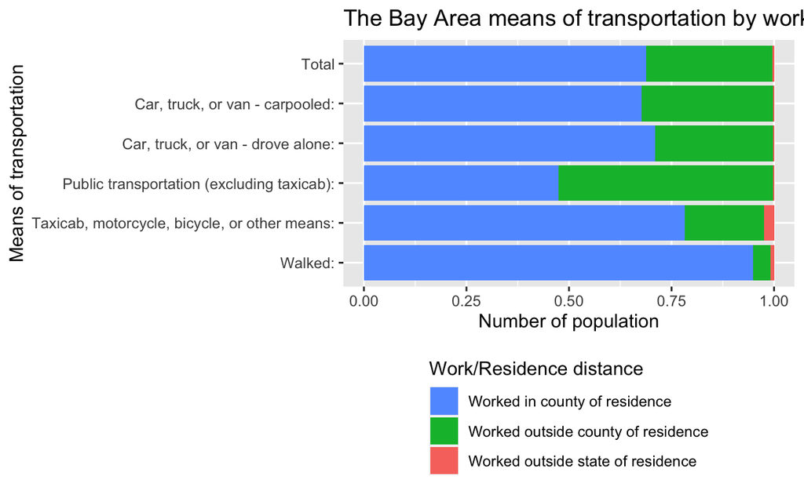

Fig. 2 The Bay Area worker commute means by work/home location

#### Means of transportation by race

The population percentage driving alone to work doesn’t vary significantly among different races in the Bay Area, as outlined in Figure 3, however the percentage of population taking public transportation is significantly higher in African American and Asian population. This still may be correlated with income status.

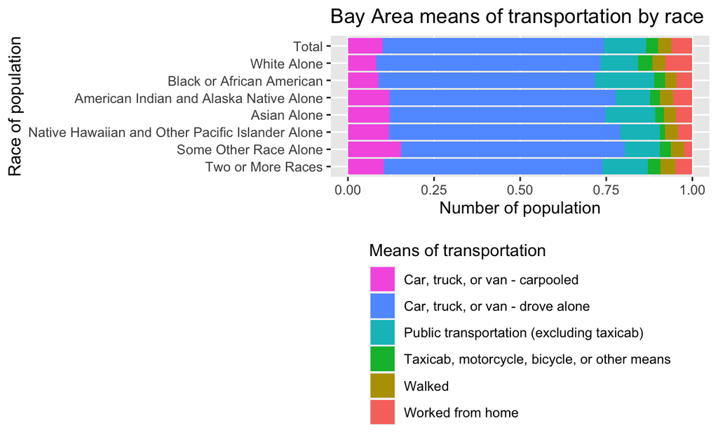

Fig. 3 The Bay Area worker commute transportation choice by race

#### Means of transportation by income

The commute choice of population by income sectors is outlined in Figure 4. Surprisingly the choice preferences for driving alone and public transportation both show a bipolar trend, with the former one having the middle income population’s preference and the latter one being favored by low income as well as extremely high income.

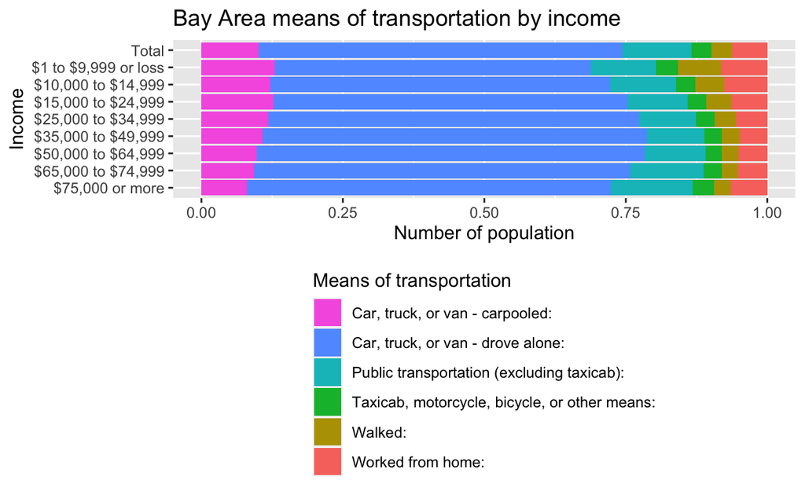

Fig. 4 The Bay Area worker commute transportation choice by income

#### Means of transportation by industry

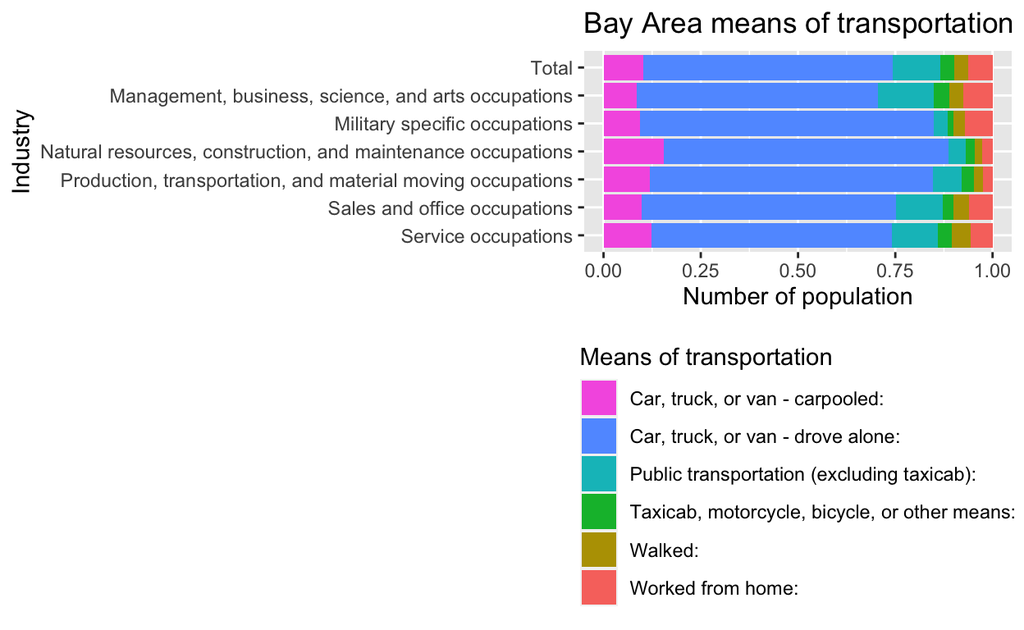

Fig. 5 The Bay Area worker commute transportation choice by industry

### Geographical inspection

#### Means of transportation to work in census tract level

As shown in Figure 6, the number of population taking public transportation to work varies significantly within the Bay Area. The population in San Francisco, Oakland, Berkeley, and the surrounding area show high predilection to public transportation where the rest of the Bay Area presents preference otherwise. More than 20% of the worker population take public transportation in the SF adjacent areas, whereas the rest of Bay Area has only 2-3% population taking the public transportation.

[interactive chart not shown]

Fig. 6 The percentage of workers taking public transportation in the Bay Area

Meanwhile, the percentage of people driving alone to work shows opposite patterns, as shown in Figure 7. As majority of the Bay Area has a rate of 55-60% of population driving alone to work, San Francisco and its adjacent areas have only 15-20% of the people choosing to drive to work places, showing once again the predilection for public transportation in the indicated area.

[interactive chart not shown]

Fig. 7 The percentage of workers driving to work in the Bay Area

#### Relationships of prevalent factors and preference for public transportation

In this section we try to build models to show the relationship between people’s preference to public transportation and other relevant variables. Before we attempt to build descriptive models to model worker’s choice of transportation and other variables, we look into the correlation between variables. As shown in Figure 8, the prevalent variables such as income, rent, and travel time to work do not show strong correlation with the choice of transportation.

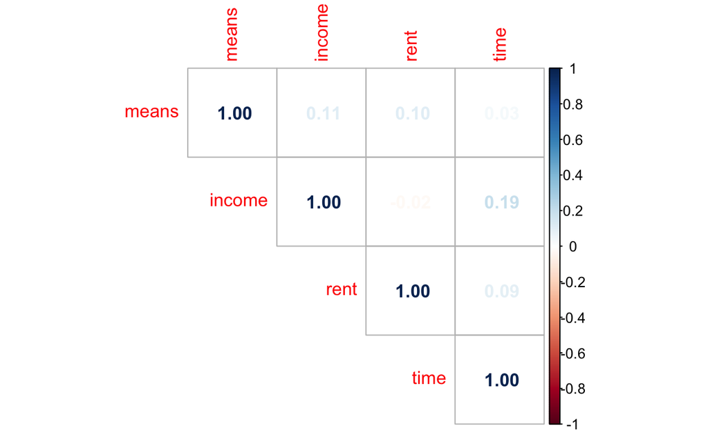

Since we focus on encouraging people to take more public transportation, we try to build regression model with the percentage of population taking public transportation and population with income over 100k, working outside of county of residence, and non-white population.

The correlation between variables described above is shown in Figure 9. As we can see, the rate of working outside of county of residence and non-white population is positively associated with public transportation preference, whereas high income is negatively associated with public transportation rate. However all correlation seems weak to be explanatory.

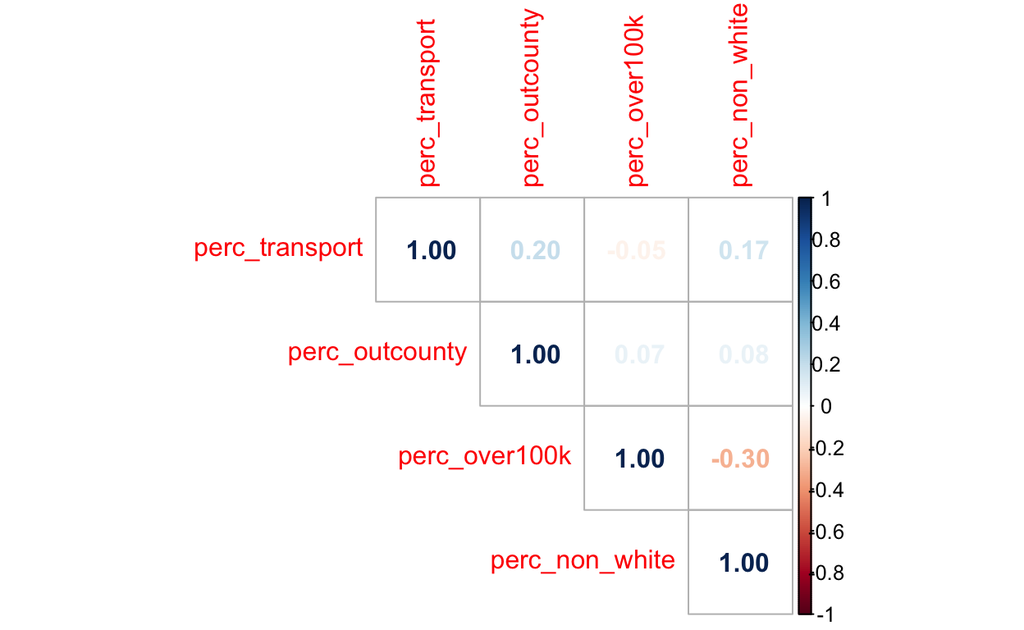

As shown in Figure 10, there is weak relationship between high income and public transport commuter percentage.

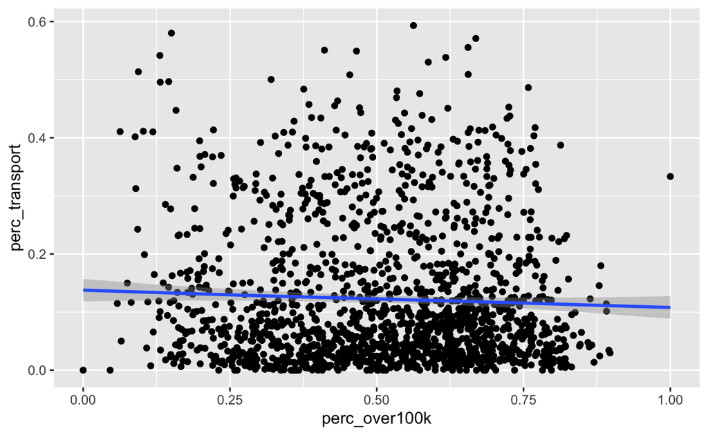

Fig. 10 The scatterplot of public transportation rate vs income over 100k rate in tract level in the Bay Area

As shown in Figure 11, there is a positive correlation between percentage of population residing outside county of work and percentage of public transport commuter. The more people work outside county of their work place, the more people taking public transportation.

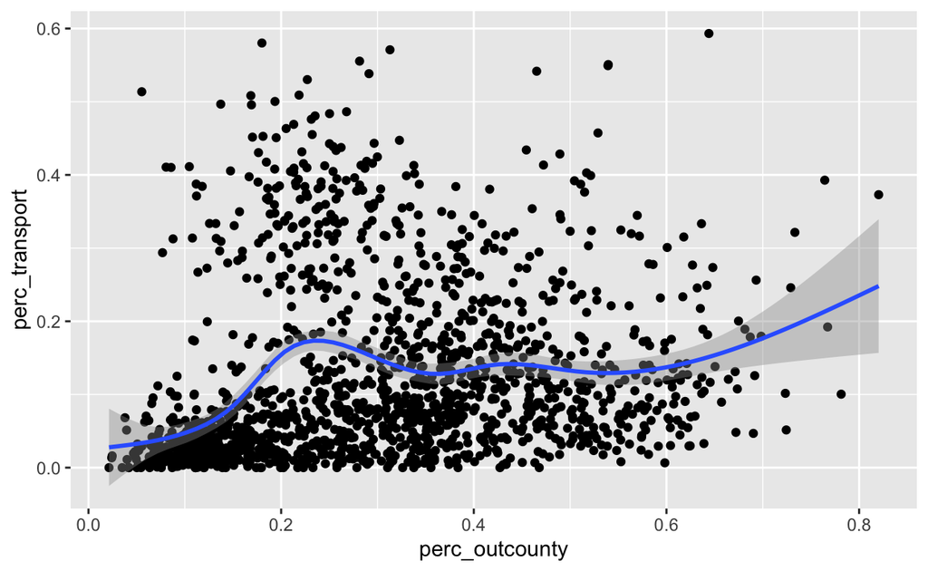

Fig. 11 The scatterplot of public transportation rate vs working-outside-of-county rate in tract level in the Bay Area

As shown in Figure 12, there is a slight trend between non-white population and the preference of public transportation. The larger percentage of non-white population, the larger preference for public transportation. However, the relationship is non-linear.

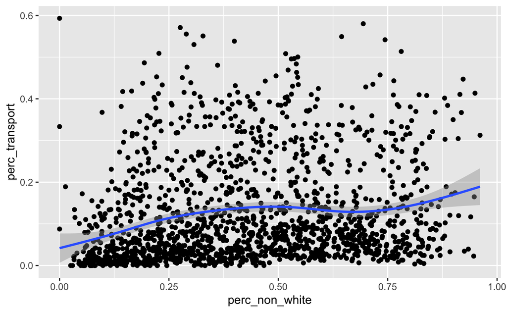

Fig. 12 The scatterplot of public transportation rate vs non-white population rate in tract level in the Bay Area

#### Bart and Caltrain accessibility

We want to know how much the availability of public transport stations affects commuters’ preference to public transportation. Since the majority of people taking public transportation resides outside of their county of residence, we take the cross-county public transportation systems as analysis objects, i.e. BART and Caltrain. Below is a map showing the Caltrain station locations in the Bay Area. As shown in Figure 13, the rail system goes through most counties in the Bay Area, which a dense focus in the San Francisco, Oakland, and Berkeley area.

[interactive chart not shown]

Fig. 13 The caltrain rail stations in the Bay Area

Similarly, the BART station distribution in the Bay Area is shown below. As shown in Figure 14, the majority of the BART stations are distributed in the San Francisco, Oakland, and Berkeley area. Even though the system extends to San Jose, the distance between each station is stretched and may cause inconvenience for commuters to get to specific locations using the BART system only.

[interactive chart not shown]

Fig. 14 The BART stations in the Bay Area

|  | Estimate | Std. Error | t value | Pr(>\|t\|) |
| --- | --- | --- | --- | --- |
| **(Intercept)** | 0.05399 | 0.01297 | 4.163 | 3.313e-05 |
| **bart** | 0.08081 | 0.01929 | 4.189 | 2.961e-05 |
| **rail** | 0.0181 | 0.01254 | 1.443 | 0.1491 |
| **perc_outcounty** | 0.1347 | 0.01886 | 7.142 | 1.399e-12 |
| **perc_over100k** | -0.01255 | 0.01711 | -0.7331 | 0.4636 |
| **perc_non_white** | 0.07119 | 0.01363 | 5.225 | 1.975e-07 |

Table 1. The coefficient table of the public transportation preference regression model in the Bay Area

| Observations | Residual Std. Error | $R^2$ | Adjusted $R^2$ |
| --- | --- | --- | --- |
| 1577 | 0.1156 | 0.08618 | 0.08327 |